# Dungeness Diet Results 1

M Fisher

2022-12-03

# Description

Summary document to produce all results figures / information for tables. Currently, figures are:

1. Prey diversity metrics:
- alpha diversity - what proportion of reads were identified down to genus or species? overall, and range per crab
- alpha diversity x stomach fullness, per crab.
- beta diversity - What was the unique number of taxa identified per per site?
- taxonomic distinctness (vegan doc)[https://search.r-project.org/CRAN/refmans/vegan/html/taxondive.html]
- species richness within each phyla
2. nMDS plot **check the distance metric here**
3. frequency (as number of crabs) of prey species
- top common prey
- unique common prey per site

Although the script is designed to work with taxa at any level, it currently uses a *species-only prey data set* (i.e., any taxa that could not be identified down to species were removed). The required inputs are: the filtered blast output (see script 5b), and a species “dictionary” in which all questionable prey IDs have been manually searched and removed.

Before generating figures / tables, the script will apply a second filter to the blast output so that it only includes species verified in the species “dictionary.”

What are the final sample sizes for this data set?

```
## # A tibble: 4 x 2
##   Site      `Crab count`
##   <chr>            <int>
## 1 KAY                 11
## 2 KAY-shell            6
## 3 LAR                 10
## 4 MARPT                2
```

# Prey Diversity

### Alpha div

What is the species richness ($\alpha$ diversity) at each site? Richness per crab is simply the species richness / total crab from site.

```
## # A tibble: 4 x 3
##   Site      ncrab species.richness
##   <chr>     <int>            <int>
## 1 KAY          11               36
## 2 KAY-shell     6               23
## 3 LAR          10               38
## 4 MARPT         2               12
```

what is the species richness ($\alpha$ diversity) per crab?

```
## species richness per crab ranges from 2 to 16
```

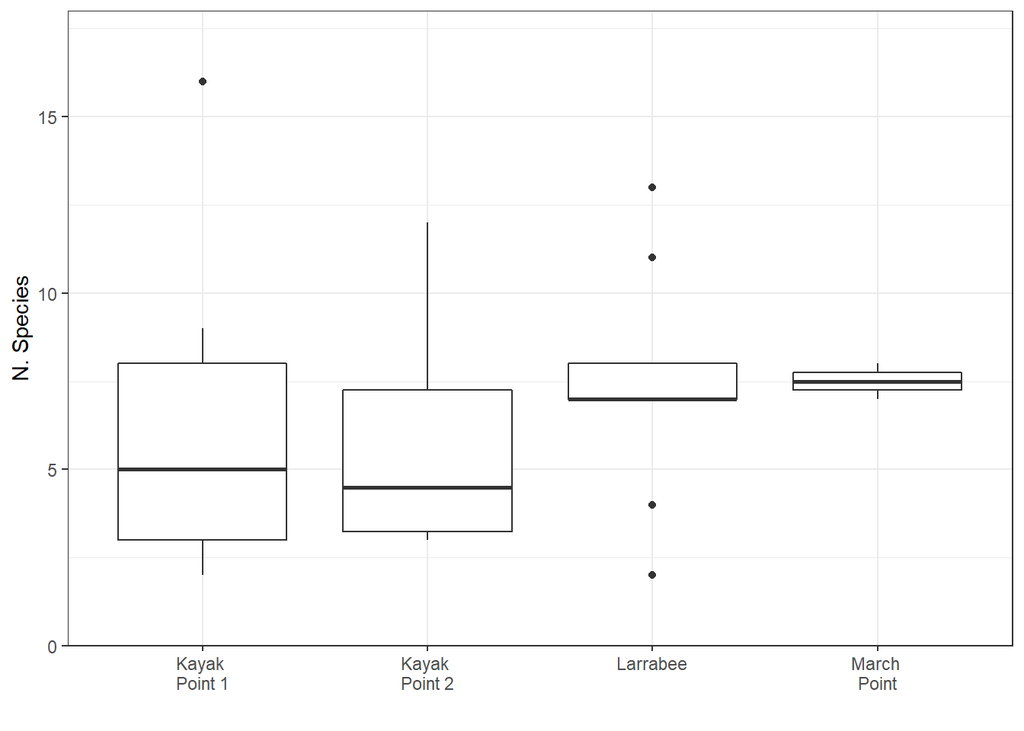

Save plot.

```r
png(here('figs','fig1_alpha-div.png'), res=200, height=600,width=800)
p.alpha
dev.off()
```

How is ($\alpha$ diversity) distributed across the taxa?

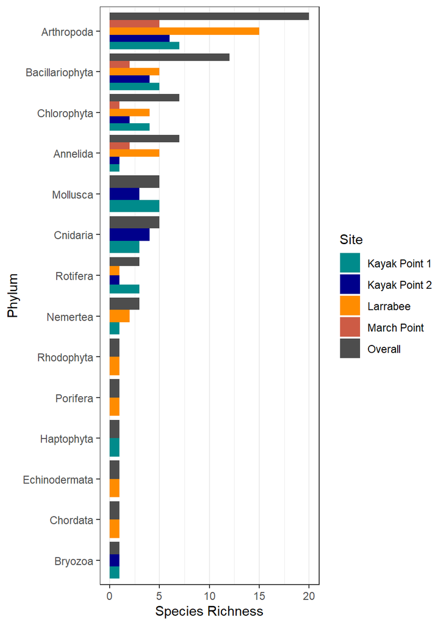

### Alpha div x Stomach Fullness

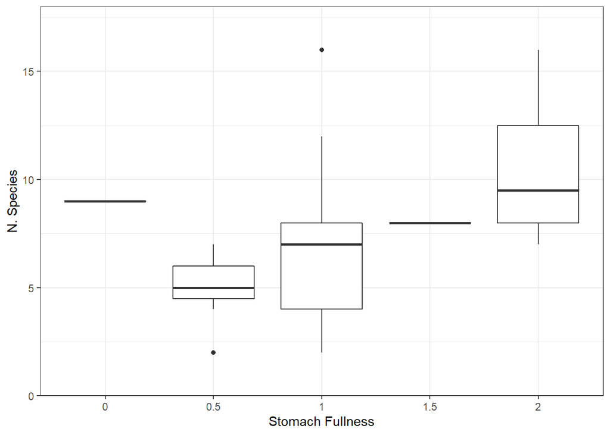

Save plot.

```r
png(here('figs','fig1b_alpha-div-fullness.png'), res=200, height=600,width=800)
p.alpha2
dev.off()
```

### Beta diversity

What is the $\beta$ diversity for species? (the ratio between regional and local species diversity) The greater the similarity in community composition between multiple communities, the lower the value of β-diversity for that set of communities.

```
##                 KAY KAY-shell       LAR     MARPT
## KAY       0.0000000 0.4754098 0.7105263 0.8800000
## KAY-shell 0.4754098 0.0000000 0.6507937 0.8918919
## LAR       0.7105263 0.6507937 0.0000000 0.7692308
## MARPT     0.8800000 0.8918919 0.7692308 0.0000000
```

Beta diversity is greater between distant sites (Kayak Point v. Clayton Beach v. March Point) than it is between neighboring sites (Kayak Point eelgrass v. shell).

### Distinctness

*Taxonomic distinctness* is the averaged taxonomic distances among species or individuals in the community (Clarke & Warwick 1998, 2001). These figures display the distinctness in prey assemblages between crab at the same site (with presence/absence data, both distinctness and diversity reduce to the same index, $\Delta^{+}$, Clarke & Warwick (1998)).

Note that this metric can only be run for those species which have their full taxonomy available:

[output not shown]

$\Delta^(+)$ per site:

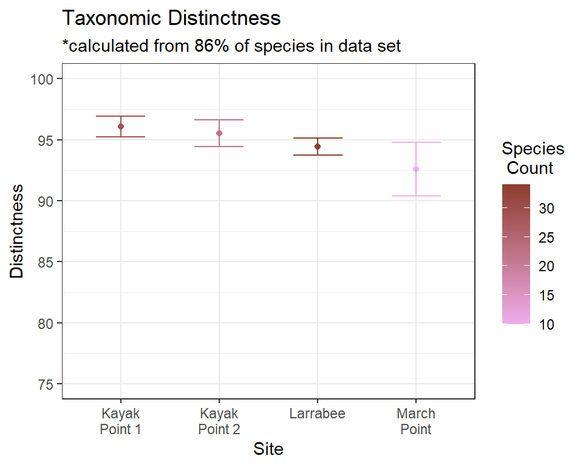

Save plot.

```r
png(here('figs','fig2_distinctness.png'), res=200, height=600,width=800)
pd1
dev.off()
```

# nMDS

Run on a presence/absence matrix, using the Jaccard dissimilarity index.

```r
z <- metaMDS(comm=crab.sp.mat, autotransform=FALSE,distance="jaccard",k=2,maxit=1000,try=40,trymax=100)
```

```
## stress: 0.195
```

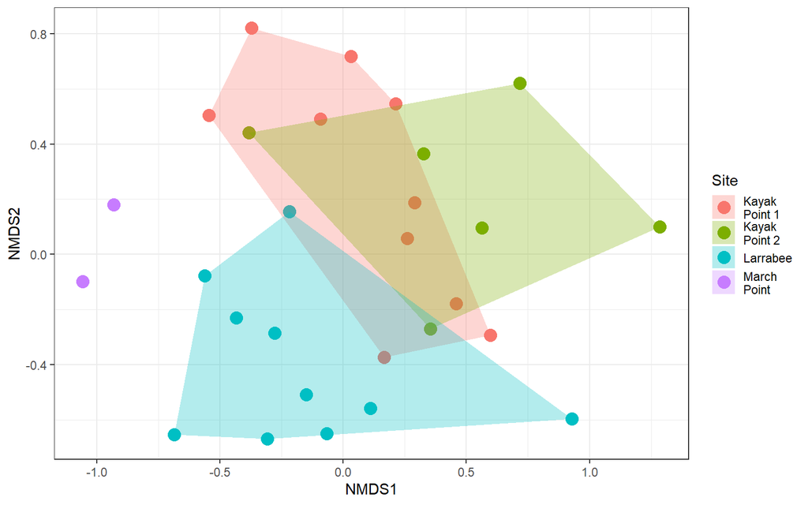

Save plot.

```r
png(here('figs','fig3_nmds.png'), res=200, height=900,width=1000)
my.nmds
dev.off()
```

# Prey identity

### common prey across all sites

Note that I removed March Point data, which comes from only two crab. With the March Point data, there was only one common species across all sites.

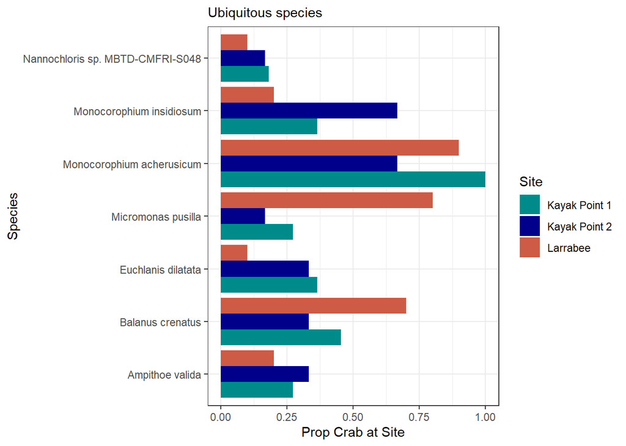

### common prey unique to sites

```
## # A tibble: 6 x 8
## # Groups:   Site, taxon, phylum, class [6]
##   Site  taxon                     phylum      class order ncrab total_crab pcrab
##   <chr> <chr>                     <chr>       <chr> <chr> <int>      <int> <dbl>
## 1 KAY   Cyclotella cryptica       Bacillario~ Cosc~ Step~     2         11 0.182
## 2 KAY   Eupolymnia heterobranchia Annelida    Poly~ Tere~     2         11 0.182
## 3 KAY   Pinnularia acrosphaeria   Bacillario~ Baci~ Navi~     2         11 0.182
## 4 LAR   Harpacticoida sp. DNZ085  Arthropoda  Hexa~ Harp~     4         10 0.4
## 5 LAR   Polydora cornuta          Annelida    Poly~ Spio~     2         10 0.2
## 6 MARPT Ampithoe lacertosa        Arthropoda  Mala~ Amph~     2          2 1
```